# ggplot ja graafika grammatika R-is

Priit Adler

2025-04-24

## Sissejuhatus (Rstudio / R)

Selle ja andmefailid leiad ELIXIREstonia githubist: https://github.com/adlerpriit/2025_taka_fall/tree/main/teemad/R

R on populaarne avatud lähtekoodiga programmeerimiskeel ja keskkond statistiliseks andmetöötluseks ja graafikute loomiseks.

RStudio on integreeritud arenduskeskkond (IDE), mis on loodud tõhusaks ja kasutajasõbralikuks R programmeerimiseks. Käivitamisel jaguneb RStudio kasutajaliides neljaks põhiosaks.

- Tekstiredaktor
- Konsool / Terminal / jne…
- Keskkond / Ajalugu / Ühendused / Git
- Failid / **Joonised** / Paketid / **Abi** / jne…

Vaata: https://rstudio.github.io/cheatsheets/html/rstudio-ide.html põhjalikuma ülevaate saamiseks.

See on kaheosalise õppetunni teine osa, mis tutvustab R-i ja ggplot2-te. Kui sa ei tunne veel R-i põhisisüntaksit, andmetüüpe ja tidyverse’i, siis vaata esmalt esimest osa: R-basic.Rmd.

## Tidyverse laadimine

```r
# Paigalda tidyverse, kui see pole veel paigaldatud
if (!requireNamespace("tidyverse", quietly = TRUE)) {
  install.packages("tidyverse")
}

# Laadi tidyverse
library(tidyverse)
```

## Andmete lugemine failist

R toetab mitmeid failiformaate andmete lugemiseks ja salvestamiseks. Levinumad formaadid:

- CSV (komaga eraldatud väärtused)
- TSV (tabiga eraldatud väärtused)
- Excel (XLS, XLSX)
- .. ja mõned teised

`tidyverse` paketid, nagu `readr` ja `readxl`, pakuvad funktsioone paljude formaatide lugemiseks. Selles töötoas keskendume CSV ja TSV failidele.

## Andmestiku kohta

Näidetes kasutame [Kaggle](https://www.kaggle.com/datasets/steveahn/memory-test-on-drugged-islanders-data?resource=download) andmestikku “**Memory Test on Drugged Islanders Data**”.

**Andmestiku kirjeldus**

Eksperiment uuris ärevusvastaste ravimite mõju mälulisele meenutusele olukorras, kus katsealuseid suunati meenutama kas rõõmsaid või kurbi mälestusi. Katse viidi läbi simuleeritud osalejatega (nn „Islander’id“), kes matkivad inimkäitumist väliste mõjutuste suhtes.

### Ravimid ja doosid

Uuritavad rühmad said erinevaid ravimeid või platseebot, igaüks kolmes doosivahemikus:

- **A – Alprazolam (Xanax, pikaajalisem toime):** 1 mg, 3 mg, 5 mg
- **T – Triazolam (Halcion, lühiajaline toime):** 0.25 mg, 0.5 mg, 0.75 mg
- **S – Platseebo (suhkrutablett):** 1, 2 või 3 tabletti

Doosid valiti nii, et need oleksid võrreldavad (1:1 suhe).

Lihtsaim viis andmete lugemiseks on kasutada `read_csv` käsku:

```r
Isd <- read_csv('../data/Islander_data.csv')
Isd
```

```
## # A tibble: 198 × 9
##    first_name last_name   age Happy_Sad_group Dosage Drug  Mem_Score_Before
##    <chr>      <chr>     <dbl> <chr>            <dbl> <chr>            <dbl>
##  1 Bastian    Carrasco     25 H                    1 A                 63.5
##  2 Evan       Carrasco     52 S                    1 A                 41.6
##  3 Florencia  Carrasco     29 H                    1 A                 59.7
##  4 Holly      Carrasco     50 S                    1 A                 51.7
##  5 Justin     Carrasco     52 H                    1 A                 47
##  6 Liam       Carrasco     37 S                    1 A                 66.4
##  7 Ava        Durand       35 S                    1 A                 44.1
##  8 Jamie      Durand       38 H                    1 A                 76.3
##  9 Josefa     Durand       29 H                    1 A                 56.2
## 10 Mark       Durand       36 S                    1 A                 54.8
## # ℹ 188 more rows
## # ℹ 2 more variables: Mem_Score_After <dbl>, Diff <dbl>
```

# Andmete kõrgetasemeline ülevaade tidyverse toru-operaatoritega (‘pipe’, `%>%`)

Tidyverse toru-operaatorid, mida tähistab `%>%` <ctrl+shift+M>, võimaldavad mitut funktsiooni järjestada selgelt ja loetavalt. Toru-operaator võtab ühe funktsiooni väljundi ja annab selle järgmise funktsiooni sisendiks, muutes andmetöötluse järjestuse lihtsasti jälgitavaks.

Järgmises näites kasutame toru-operaatorit, et teha järjestikuseid toiminguid: 1. Rühmitame andmed kategooria järgi (`group_by`) 2. Arvutame iga rühma kohta kokkuvõtlikud näitajad (`summarize`) 3. Sorteerime tulemused kindla näitaja järgi (`arrange`)

```r
# Andmete kokkuvõte
data_summary <- data %>%
  group_by(YourCategory) %>%
  summarize(
    mean_value = mean(YourVariable, na.rm = TRUE),
    n = n()
  ) %>%
  arrange(desc(mean_value))

head(data_summary)
```

```
## # A tibble: 5 × 3
##   YourCategory mean_value     n
##   <fct>             <dbl> <int>
## 1 B                  50.7    25
## 2 A                  50.0    20
## 3 C                  49.6    11
## 4 E                  49.1    24
## 5 D                  46.5    20
```

Ülaltoodud koodis asenda `YourCategory` ja `YourVariable` oma andmestiku veergude nimedega. See annab kõrgetasemelise ülevaate, rühmitades andmed ja arvutades keskmise. toru-operaatorid muudavad andmetöötluse järjestuse hästi jälgitavaks.

```r
# Uus veerg mutate ja case_when abil
# pane tähele, et kirjutame (uuendame) originaalandmestikku
data <- data %>%
  mutate(
    HalfOfOtherVariable = YourOtherVariable / 2, # lisame uue veeru olemasolevate põhjal
    YourGroup = case_when(
      YourCategory %in% c("A", "B") ~ "Grupp 1", # ühendame A ja B Grupp 1-ks
      YourCategory %in% c("C", "D") ~ "Grupp 2", # ühendame C ja D Grupp 2-ks
      TRUE ~ "Muu"                              # case_when vajab vaikimisi väärtust
    ),
    NewVariable = case_when(
      YourVariable > 60 ~ YourVariable * 2,  # Korrutame üle 60 väärtused kahega
      YourVariable < 40 ~ YourVariable / 2,  # Jagame alla 40 väärtused kahega
      TRUE ~ YourVariable                    # Muud jätame samaks
    )
  )
head(data)
```

```
## # A tibble: 6 × 6
##   YourCategory YourVariable YourOtherVariable HalfOfOtherVariable YourGroup
##   <fct>               <dbl>             <dbl>               <dbl> <chr>
## 1 A                    56.2              16.5                8.25 Grupp 1
## 2 E                    40.5              23.4               11.7  Muu
## 3 A                    44.6              21.7               10.9  Grupp 1
## 4 A                    55.8              19.7                9.85 Grupp 1
## 5 B                    57.7              17.1                8.55 Grupp 1
## 6 D                    54.6              21.3               10.6  Grupp 2
## # ℹ 1 more variable: NewVariable <dbl>
```

Rstudio arendajad pakuvad mitmeid kasulikke [spikreid](https://posit.co/resources/cheatsheets/), vaata kindlasti. Näiteks [data transformatsioonid dplyr-iga](https://rstudio.github.io/cheatsheets/data-transformation.pdf) (dplyr kuulub tidyverse’i).

### Ülesanne:

**Ülesanne: Uimastite mõju analüüs mälule**

Kasutades andmestikku “Memory Test on Drugged Islanders Data”, analüüsi erinevate ravimite ja nende dooside mõju mälu taastamisele.

1. **Vanuserühma veerg**:
   - Loo andmestikku uus veerg nimega **`age_group`**. Kategoriseeri osalejad: “Noor” (alla 30), “Keskealine” (30-50), “Seenior” (üle 50). (*vihje:* `case_when`)

```r
# Loo vanuserühma veerg
Isd <- Isd %>%
  mutate(age_group = case_when(
    age < 30  ~ "Noor",
    age <= 50 ~ "Keskealine",
    age > 50  ~ "Seenior"
  ),
  age_group = factor(age_group, levels = c("Noor", "Keskealine", "Seenior")))

count(Isd, age_group)
```

```
## # A tibble: 3 × 2
##   age_group      n
##   <fct>      <int>
## 1 Noor          49
## 2 Keskealine   111
## 3 Seenior       38
```

# Joonistamine ggplot2-ga

ggplot2 pakett R-is järgib “Graafika grammatika” modulaarset paradigmat. See lähenemine võimaldab kasutajal ehitada keerukaid jooniseid, kombineerides lihtsaid komponente ehk kihte. Iga kiht esindab kindlat osa joonisest, näiteks andmed, esteetikad, geomid, skaalad ja teemad.

1. **data**: Iga joonise alus. Määrad, millist andmestikku soovid visualiseerida.
2. **aesthetics(aes)**: Esteetikad on joonise visuaalsed omadused, nagu x- ja y-telg, värv, suurus, kuju ja läbipaistvus. Määrad, millised muutujad andmestikust vastavad millistele esteetikatele.
3. **geom**: Geomid (geomeetrilised objektid) on tegelikud joonise elemendid, nagu punktid, jooned ja tulbad. Erinevad geomid tähistavad erinevat tüüpi jooniseid, nt hajuvusdiagramm, joondiagramm või tulpdiagramm. Ühele joonisele saab lisada mitu geom-i.
4. **scale**: Skaalad määravad, kuidas andmeväärtused teisendatakse esteetilisteks omadusteks. Näiteks värvid, suurused või kujundid. Skaalasid saab kohandada joonise välimuse muutmiseks.
5. **theme**: Kujundab joonise mitte-andmelisi aspekte, nagu taust, ruudustik, telgede sildid ja legend. Kujundust (`theme`) muutes saab joonise välimust muuta.

ggplot2 modulaarse lähenemise puhul alustad andmete ja esteetikate määramisest, seejärel lisad geom-e, skaalasid ja teemasid vastavalt vajadusele. Selline kihiline lähenemine võimaldab luua väga erinevaid jooniseid, kombineerides ja kohandades neid komponente.

Näide, mis demonstreerib modulaarset lähenemist:

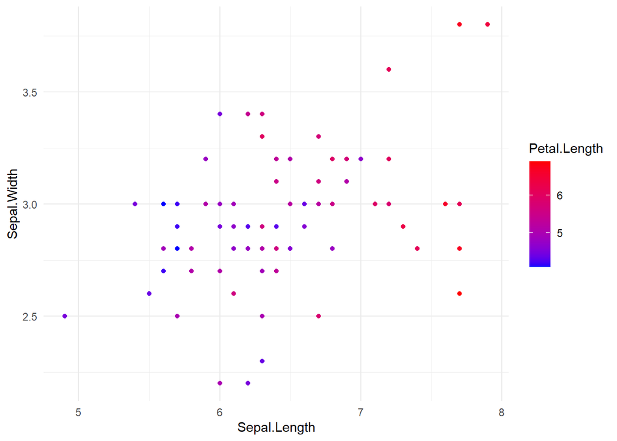

```r
# Määra andmed ja esteetikad
plot <- ggplot(data = iris %>% filter(Petal.Length > 4), aes(x = Sepal.Length, y = Sepal.Width, color = Petal.Length)) +
  geom_point() +
  scale_color_continuous(low = "blue", high = "red") +
  theme_minimal()

# Kuvab joonise
plot
```

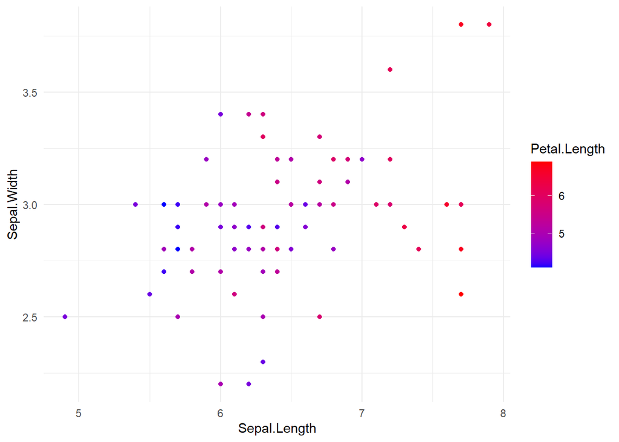

```r
iris %>%
  filter(Petal.Length > 4) %>%
  ggplot(aes(x=Sepal.Length, y=Sepal.Width, color=Petal.Length)) +
  geom_point() +
  scale_color_continuous(low='blue', high='red') +
  theme_minimal()
```

## Esteetikad ggplot2-s

Esteetikad on joonise elementide visuaalsed omadused. Need aitavad esile tuua andmete mustreid ja seoseid. ggplot2-s seotakse andmestiku muutujad esteetikatega, et luua seos andmete ja joonise elementide vahel. Levinumad esteetikad on `x` ja `y` telg, `color`, `size`, `shape`, `group` ja `transparency`.

### Esteetikate määramine

Loome hajuvusdiagrammi, kus `age` on x-teljel, `Diff` y-teljel ja `Drug` värvi esteetikana:

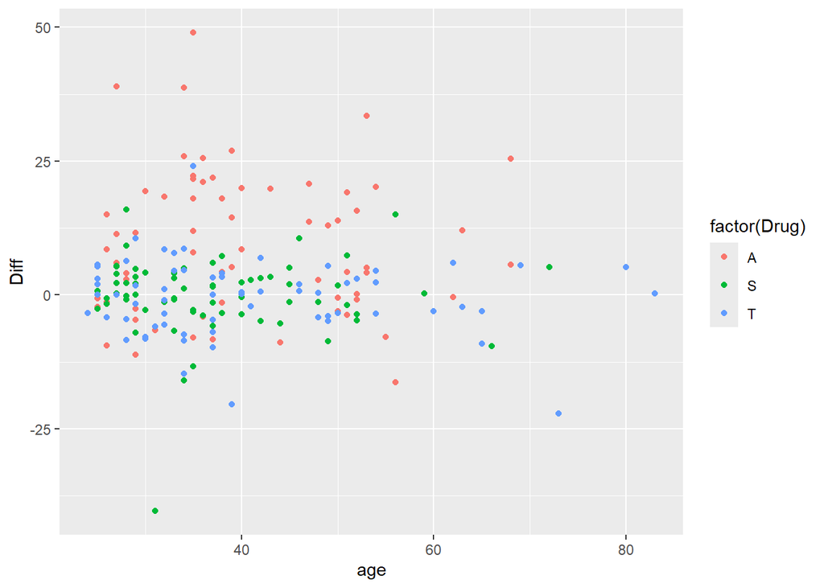

```r
# Hajuvusdiagramm, kus esteetikad on seotud muutujatega
scatter_plot <- ggplot(Isd, aes(x = age, y = Diff, color = factor(Drug))) +
  geom_point()

scatter_plot
```

### Esteetikate muutmine ja geom-is ülekirjutamine

Esteetika omadusi saab muuta otse geom-is. See võimaldab muuta konkreetsete joonise elementide välimust. Loome hajuvusdiagrammi, kus punktid on suuremad ja läbipaistvamad:

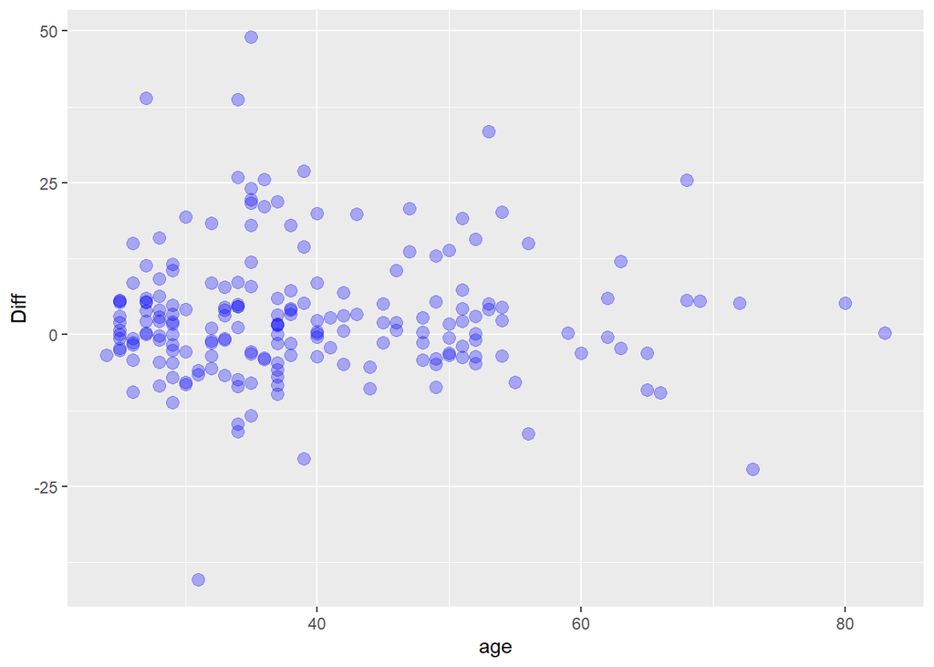

```r
# Muuda punktide suurust ja läbipaistvust geom-is
scatter_plot_independent_aes <- ggplot(Isd, aes(x = age, y = Diff)) +
  geom_point(size = 3, alpha = 0.3, color='blue')

scatter_plot_independent_aes
```

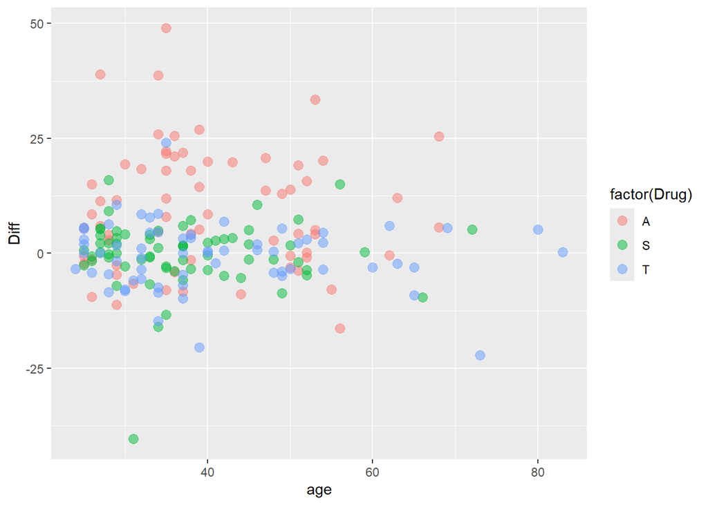

```r
scatter_plot_data_related_aes <- ggplot(Isd, aes(x = age, y = Diff)) +
  geom_point(size = 3, alpha = 0.5, aes(color = factor(Drug)))

scatter_plot_data_related_aes
```

Selles näites suurendasime punktide suurust ja muutsime need poolläbipaistvaks, määrates `size` ja `alpha` geom_point() sees. Esteetikate muutmine geom-is võimaldab algseid seoseid üle kirjutada ja joonise välimust täpsemalt kontrollida.

## Erinevate geom-ide kasutamine

Selles osas demonstreerime erinevaid geom-e lihtsa näidisandmestikuga. Iga geom esindab kindlat tüüpi joonist ja nende sobivus sõltub andmete tüübist (arvuline vs. kategooriline) ning sellest, millist seost soovid visualiseerida.

### Hajuvusdiagramm (scatterplot, geom_point)

Hajuvusdiagramm näitab kahe arvulise muutuja seost, joonistades punktid nende x- ja y-koordinaatidele. Kasulik mustrite, trendide või erandite leidmiseks.

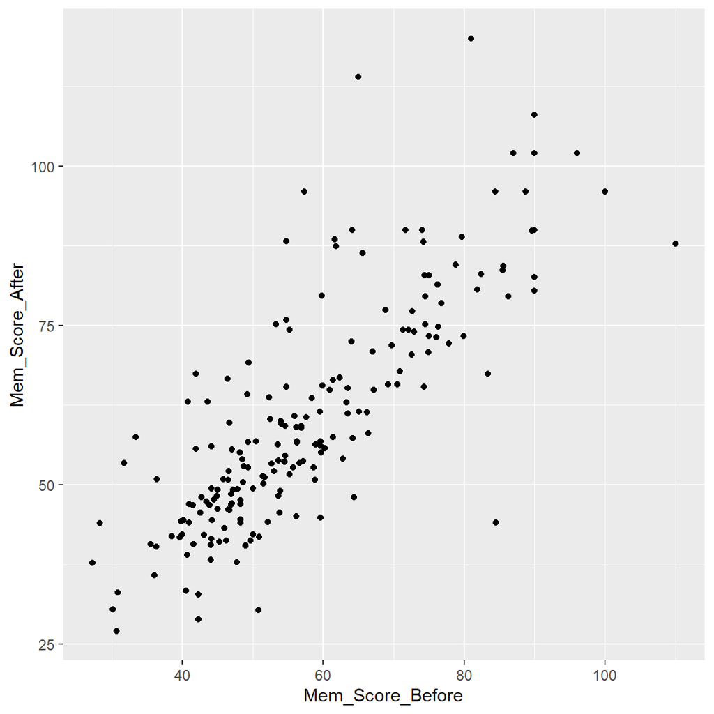

```r
# Kasuta Islander andmestikku näitena
# head(Isd)

# Hajuvusdiagramm mälu skoorist enne ja pärast ravimi võtmist
scatter_plot <- ggplot(Isd, aes(x = Mem_Score_Before, y = Mem_Score_After)) +
  geom_point()

scatter_plot
```

### Joondiagramm (line plot, geom_line)

Joondiagramm ühendab andmepunktid joontega, et näidata kahe arvulise muutuja vahelist seost. Kasulik trendide näitamiseks ajas või muutuvas suuruses.

```r
# Kasuta pressure andmestikku näitena
head(pressure)
```

```
##   temperature pressure
## 1           0   0.0002
## 2          20   0.0012
## 3          40   0.0060
## 4          60   0.0300
## 5          80   0.0900
## 6         100   0.2700
```

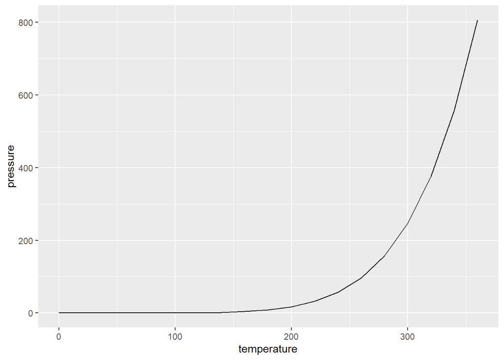

```r
# Joondiagramm temperatuurist vs. rõhk
line_plot <- ggplot(pressure, aes(x = temperature, y = pressure)) +
  geom_line()

line_plot
```

### Tulpdiagramm (geom_bar) ja veerudiagramm (geom_col)

Tulpdiagramm näitab kategooriliste andmete sagedust või arvu, veerudiagramm näitab arvulise muutuja väärtust iga kategooria kohta. Mõlemad sobivad kategooriliste ja arvuliste muutujate seoste visualiseerimiseks.

```r
# Kasuta Islander andmestikku näitena
head(Isd)
```

```
## # A tibble: 6 × 10
##   first_name last_name   age Happy_Sad_group Dosage Drug  Mem_Score_Before
##   <chr>      <chr>     <dbl> <chr>            <dbl> <chr>            <dbl>
## 1 Bastian    Carrasco     25 H                    1 A                 63.5
## 2 Evan       Carrasco     52 S                    1 A                 41.6
## 3 Florencia  Carrasco     29 H                    1 A                 59.7
## 4 Holly      Carrasco     50 S                    1 A                 51.7
## 5 Justin     Carrasco     52 H                    1 A                 47
## 6 Liam       Carrasco     37 S                    1 A                 66.4
## # ℹ 3 more variables: Mem_Score_After <dbl>, Diff <dbl>, age_group <fct>
```

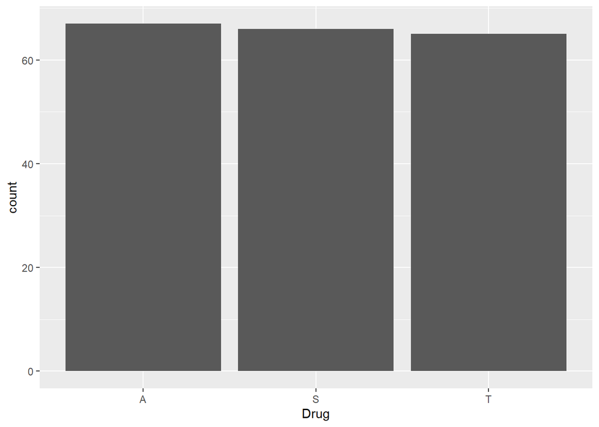

```r
# Kategooriliste andmete puhul loe, mitu korda iga esineb
bar_plot <- ggplot(Isd, aes(x = Drug)) +
  geom_bar()

bar_plot
```

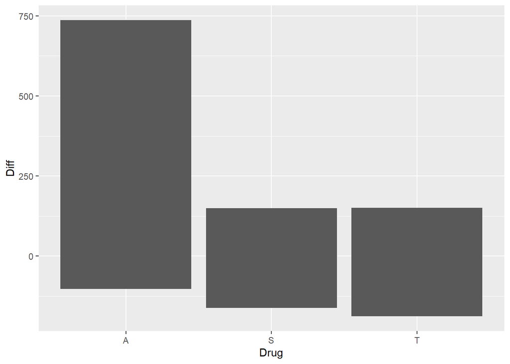

```r
# Arvuliste andmete puhul summeerib kõik väärtused x-telje kategooriate kaupa
column_plot <- ggplot(Isd, aes(x = Drug, y = Diff)) +
  geom_col()

column_plot
```

### Histogramm (geom_histogram)

Histogramm jagab arvulised andmed vahemikeks (bin-ideks) ja näitab iga vahemiku sagedust. Kasulik arvulise muutuja jaotuse visualiseerimiseks.

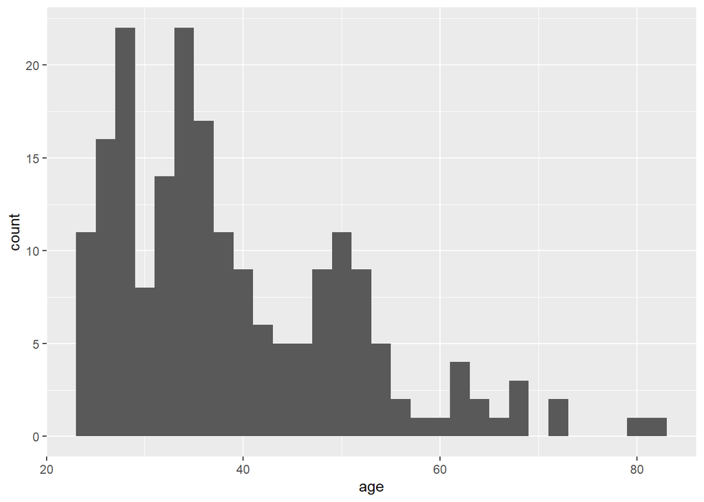

```r
# Histogramm vanuse kohta Islander andmestikus
histogram_plot <- ggplot(Isd, aes(x = age)) +
  geom_histogram(binwidth = 2)

histogram_plot
```

### Kastdiagramm (geom_boxplot)

Kastdiagramm näitab arvulise muutuja jaotust erinevate kategooriate lõikes. Kasulik jaotuste võrdlemiseks ja erandite leidmiseks kategooriates.

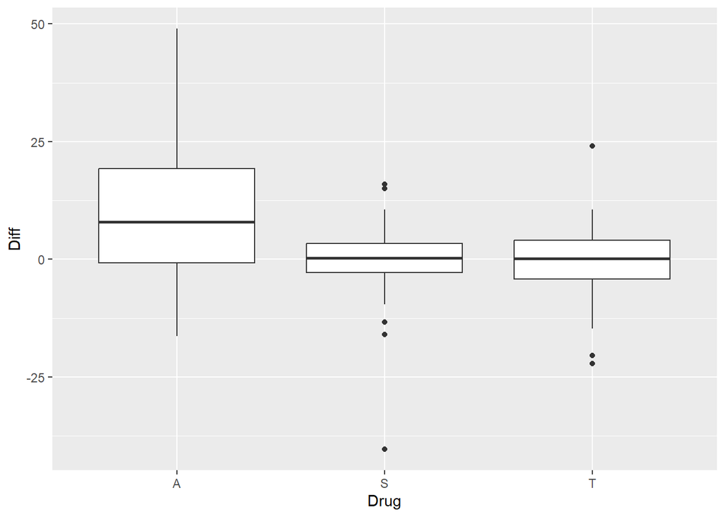

```r
# Kastdiagramm Diff väärtuse kohta ravimite lõikes
box_plot <- ggplot(Isd, aes(x = Drug, y = Diff)) +
  geom_boxplot()

box_plot
```

Need on vaid mõned näited paljudest ggplot2 geom-idest. Õige geom-i valik aitab luua informatiivseid ja visuaalselt atraktiivseid jooniseid, mis toovad esile andmete seosed.

## Positsiooni kohandused ja mitme kihi lisamine

### Punktide hajutamine (position = “jitter”)

Hajuvusdiagrammides võivad punktid kattuda, mistõttu on raske üksikuid vaatlusi eristada. Selle lahendamiseks saab kasutada positsiooni kohandust `jitter`, mis liigutab punkte juhuslikult, et kattuvust vähendada.

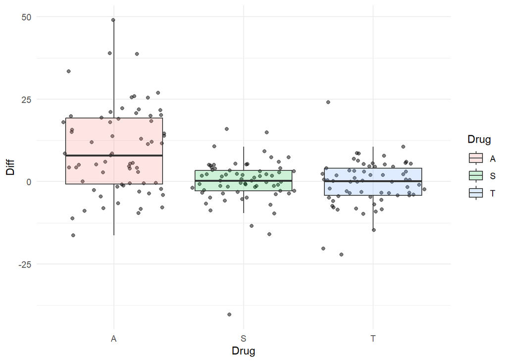

```r
jittered_plot <- ggplot(Isd, aes(x = Drug, y = Diff)) +
  geom_point(position = position_jitter(width = 0.4), alpha = 0.5) +
  geom_boxplot(aes(fill = Drug), alpha = 0.2, outlier.shape = NA) +
  theme_minimal()

jittered_plot
```

Selles näites on punktid hajutatud, et vähendada kattuvust ja muuta vaatluste jaotus kategooriates paremini nähtavaks.

### Mitme kihi (geom-i) lisamine

Ühele joonisele saab lisada mitu geom-i, et luua keerukamaid visualiseeringuid. Näiteks saab hajuvusdiagrammi kombineerida silutud joonega, mis näitab üldist trendi, ning lisada tekstisildid konkreetsete punktide tähistamiseks.

```r
# Kasuta mtcars andmestikku näitena
head(mtcars)
```

```
##                    mpg cyl disp  hp drat    wt  qsec vs am gear carb
## Mazda RX4         21.0   6  160 110 3.90 2.620 16.46  0  1    4    4
## Mazda RX4 Wag     21.0   6  160 110 3.90 2.875 17.02  0  1    4    4
## Datsun 710        22.8   4  108  93 3.85 2.320 18.61  1  1    4    1
## Hornet 4 Drive    21.4   6  258 110 3.08 3.215 19.44  1  0    3    1
## Hornet Sportabout 18.7   8  360 175 3.15 3.440 17.02  0  0    3    2
## Valiant           18.1   6  225 105 2.76 3.460 20.22  1  0    3    1
```

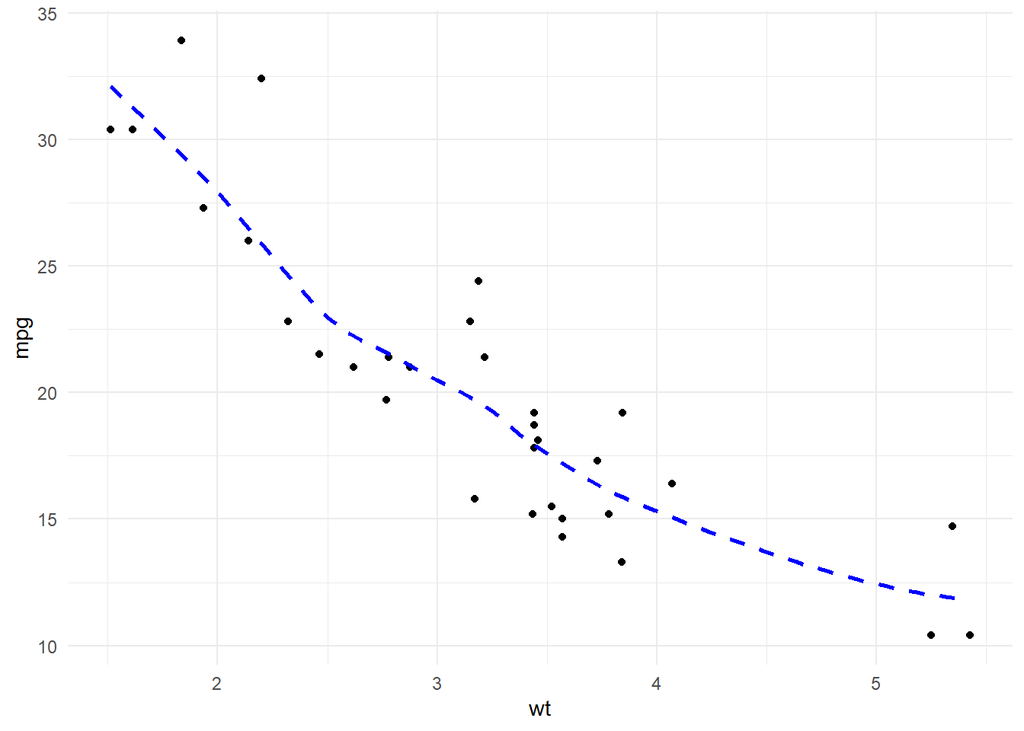

```r
# Hajuvusdiagramm mpg vs. wt koos silutud joonega
scatter_plot_smooth <- ggplot(mtcars, aes(x = wt, y = mpg)) +
  geom_point() +
  geom_smooth(formula = y ~ x, method = "loess", se = FALSE, linetype = "dashed", color = "blue") +
  theme_minimal()

scatter_plot_smooth
```

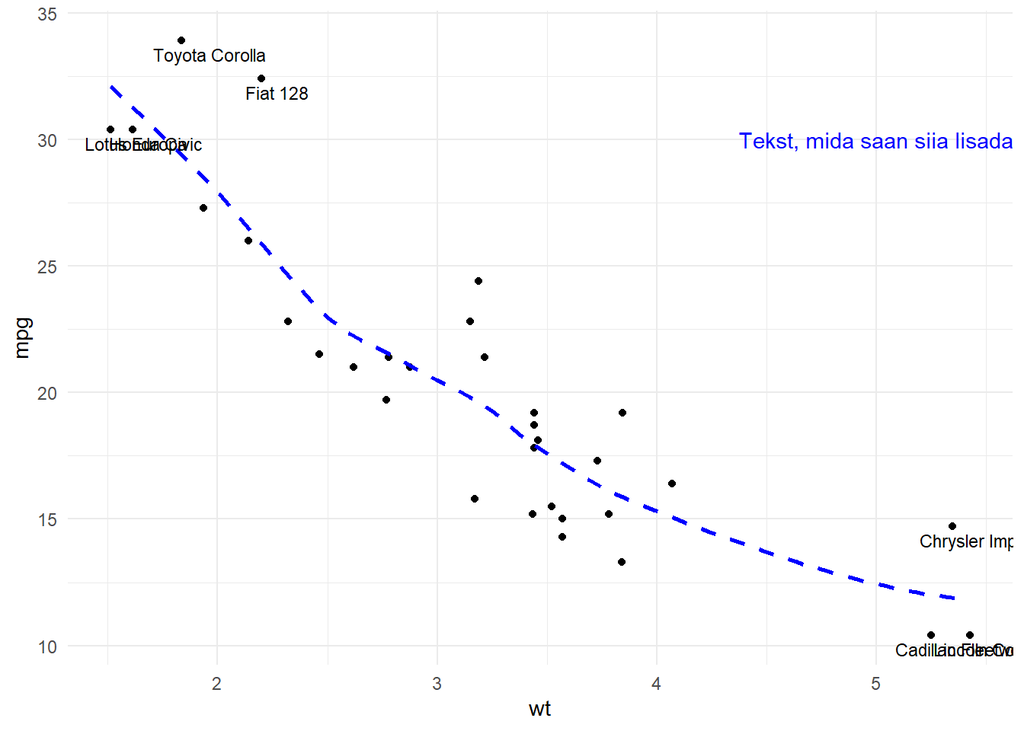

```r
# Märgi konkreetseid andmepunkte tekstiga
scatter_plot_annotate <- scatter_plot_smooth +
  geom_text(data = subset(mtcars, mpg > 30 | wt > 5),
            size = 3, hjust = 0.25, vjust = 1.5,
            mapping = aes(label=rownames(subset(mtcars, mpg > 30 | wt > 5)))) +
  annotate(geom = 'text', x = 5, y = 30, label="Tekst, mida saan siia lisada", color="blue")

scatter_plot_annotate
```

Selles näites loodi esmalt hajuvusdiagramm mpg vs. wt ja lisati silutud joon geom_smooth abil. Seejärel märgiti konkreetseid andmepunkte tekstiga geom_text abil. Mitme geom-i kombineerimine võimaldab luua informatiivsemaid ja visuaalselt atraktiivsemaid jooniseid.

### Ülesanne:

Kasuta allolevat lahtrit, et korrata seni tehtud samme. Koosta joonis, kus kuvad `Islander_data` andmeid `Drug` ja `Diff` järgi. Kasuta `geom_violin`-it, mida see näitab ja kuidas seda tõlgendada? Lisa sinna ka `geom_point`, tee see väga heledaks (läbipaistvaks), kasuta positsiooni `jitter`. Rohkem võimalusi leiad [data-transformations](https://rstudio.github.io/cheatsheets/data-transformation.pdf) spikrilt.

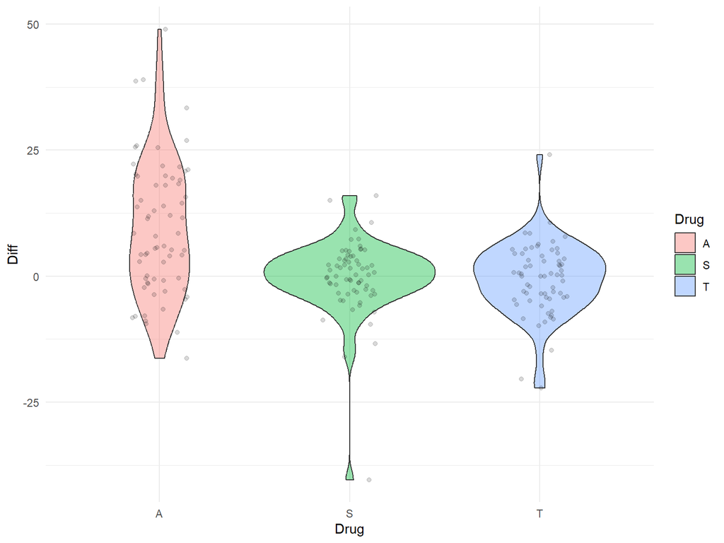

```r
ggplot(Isd, aes(x = Drug, y = Diff)) +
  geom_violin(aes(fill = Drug), alpha = 0.4) +
  geom_point(position = position_jitter(width = 0.15, height = 0), alpha = 0.15) +
  theme_minimal()
```

Violin näitab jaotuse kuju ja mida laiem see on, seda rohkem vaatlusi selle väärtuse juures on. Erinevalt kastdiagrammist on näha ka see, kas jaotusel on üks või mitu tippu. Platseebo ja triasolaami väärtused on koondunud väikesesse vahemikku nulli ümber, ehk mälu skoor keskmiselt ei muutunud. Platseebol on küll üks märkimisväärne erand, kelle skoor langes umbes 40 punkti. Alprasolaami jaotus on palju laiem ja nihkunud üles, mediaan on umbes 8 ja ühel osalejal isegi ligi 50. Ravim seega parandas mälu, aga efekt erines inimeseti tugevalt. Punktid näitavad kõiki vaatluseid iga rühma kohta (iga violin põhineb umbes 65 vaatlusel).

## Arvuliste ja diskreetsete muutujate skaleerimine

Muutujate skaleerimine võimaldab nende väärtuste vahemikku muuta, et andmeid paremini visualiseerida või võrrelda erinevate ühikutega muutujaid.

### Arvuliste muutujate skaleerimine

Arvuliste muutujate puhul saab kasutada `scale_x_continuous()` ja `scale_y_continuous()` x- ja y-telje skaala muutmiseks. mtcars andmestik sobib hästi selle näitamiseks.

Näide: Hobujõu logaritmiline teisendus. Loome hajuvusdiagrammi mpg vs. hp ja skaleerime y-telje logaritmiliselt:

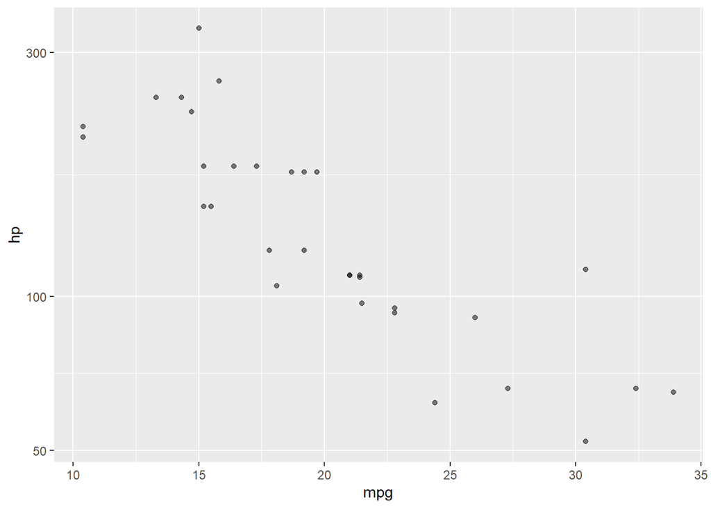

```r
# Hajuvusdiagramm logaritmilise y-teljega mtcars andmetel
scatter_plot_scaled <- ggplot(mtcars, aes(x = mpg, y = hp)) +
  geom_point(alpha = 0.5) +
  scale_y_log10()

scatter_plot_scaled
```

Selles näites aitab hobujõu logaritmiline teisendus tuua esile seoseid kütusesäästlikkuse (mpg) ja mootori võimsuse (hp) vahel, mis muidu võivad originaalskaalal varjatuks jääda.

### Diskreetsete muutujate skaleerimine

Diskreetsete muutujate puhul saab kasutada `scale_x_discrete()` ja `scale_y_discrete()` kategooriate järjekorra või välimuse muutmiseks. mtcars andmestikus saab uurida, kuidas silindrite arv (cyl) mõjutab kütusesäästlikkust (mpg).

Näide: Silindrite kategooriate ümberjärjestamine mediaani mpg järgi. Loome kastdiagrammi silindrite arvu ja mpg kohta ning järjestame silindrite kategooriad mediaani mpg järgi:

```r
# Arvuta iga silindrite kategooria mediaan mpg
cyl_median <- mtcars %>%
  group_by(cyl) %>%
  summarize(median_mpg = median(mpg, na.rm = TRUE)) %>%
  arrange(median_mpg)

cyl_median
```

```
## # A tibble: 3 × 2
##     cyl median_mpg
##   <dbl>      <dbl>
## 1     8       15.2
## 2     6       19.7
## 3     4       26
```

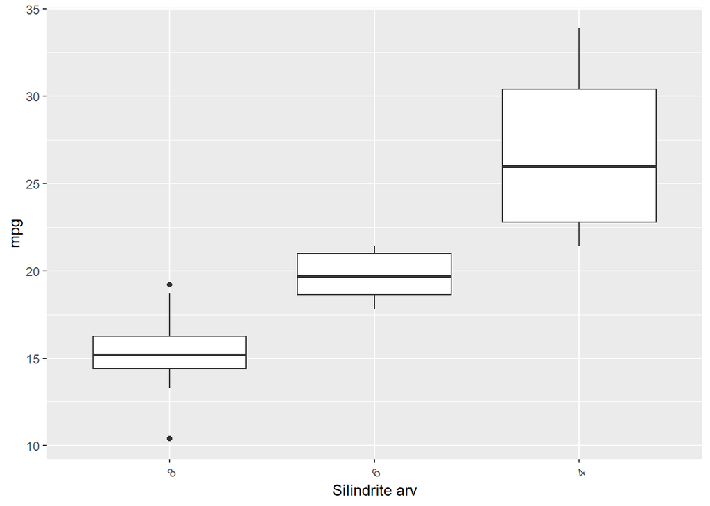

```r
# Kastdiagramm ümberjärjestatud silindrite kategooriatega
box_plot_scaled <- ggplot(mtcars, aes(x = factor(cyl), y = mpg)) +
  geom_boxplot() +
  scale_x_discrete(limits = factor(cyl_median$cyl)) +
  theme(axis.text.x = element_text(angle = 45, hjust = 1)) +
  xlab("Silindrite arv")

box_plot_scaled
```

Selles näites aitab silindrite arvu ümberjärjestamine mediaani mpg järgi tuua esile erinevused kütusesäästlikkuses erineva mootorisuurusega autodel. See lihtsustab võrdlust.

Muutujate skaleerimine parandab jooniste loetavust ja aitab tuua esile varjatud mustreid. Õigete teisenduste rakendamine muudab visualiseeringud tõhusamaks.

## Värviskaala muutmine

Värviskaala abil saab joonisel visualiseerida lisamuutujat, lisades andmetesse täiendava mõõtme. Selles näites loome kastdiagrammi silindrite arvu (**`cyl`**) ja kütusesäästlikkuse (**`mpg`**) kohta, kus punktide värv näitab mootori mahtu (**`disp`**).

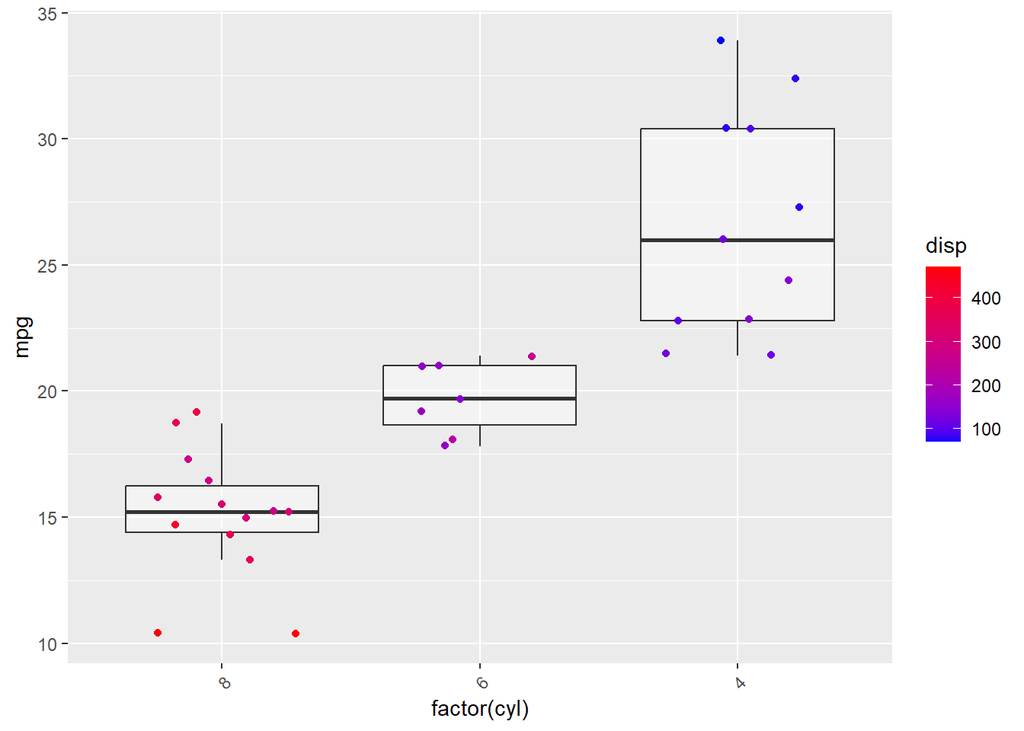

```r
# Kastdiagramm ümberjärjestatud silindrite kategooriatega ja värviskaalaga
box_plot_color_scaled <- ggplot(mtcars, aes(x = factor(cyl), y = mpg)) +
  geom_boxplot(alpha = 0.4, outlier.shape = NA) +  # täitmine disp järgi
  geom_jitter(aes(color = disp), width = 0.3) +  # hajutatud punktid värvitud disp järgi
  scale_x_discrete(limits = factor(cyl_median$cyl)) +
  scale_color_gradient(low = "blue", high = "red") +  # värviskaala punktidele
  theme(axis.text.x = element_text(angle = 45, hjust = 1))

box_plot_color_scaled
```

Värviskaala rakendamine muudab visualiseeringud informatiivsemaks ja aitab paremini mõista andmete seoseid. See on eriti kasulik keerukate seoste avastamisel ja esitamisel.

## Faktorandmete ümberkodeerimine ja ümberjärjestamine

Faktorid on kategoorilised muutujad, millel on piiratud arv väärtusi. ggplot2-s saab faktoreid ümberkodeerida ja ümber järjestada, et visualiseeringuid parandada.

### Ümberkodeerimine

Ümberkodeerimine tähendab faktori tasemete muutmist. Selleks saab kasutada `forcats` paketti (kuulub tidyverse’i). Funktsioon `fct_recode()` võimaldab tasemeid ümber nimetada. Vaata ka [spikrit](https://rstudio.github.io/cheatsheets/factors.pdf).

```r
# Laadi vajalikud paketid
library(forcats)

# # Kodeeri Drug muutuja ümber
Isd_refactored <- Isd %>%
  mutate(Drug_name = fct_recode(Drug,
                                "Alprazolam" = "A",
                                "Triazolam" = "T",
                                "Suhkur" = "S"))

head(Isd_refactored)
```

```
## # A tibble: 6 × 11
##   first_name last_name   age Happy_Sad_group Dosage Drug  Mem_Score_Before
##   <chr>      <chr>     <dbl> <chr>            <dbl> <chr>            <dbl>
## 1 Bastian    Carrasco     25 H                    1 A                 63.5
## 2 Evan       Carrasco     52 S                    1 A                 41.6
## 3 Florencia  Carrasco     29 H                    1 A                 59.7
## 4 Holly      Carrasco     50 S                    1 A                 51.7
## 5 Justin     Carrasco     52 H                    1 A                 47
## 6 Liam       Carrasco     37 S                    1 A                 66.4
## # ℹ 4 more variables: Mem_Score_After <dbl>, Diff <dbl>, age_group <fct>,
## #   Drug_name <fct>
```

Selles näites kodeerisime `Drug` muutuja tasemed tähtedest tegelike ravimite nimedeks.

### Ümberjärjestamine

Ümberjärjestamine tähendab faktori tasemete järjekorra muutmist. Selleks saab kasutada `fct_reorder()` funktsiooni, mis järjestab tasemed teise muutuja väärtuste alusel.

```r
# Loo uus veerg, kus Drug_name on ümberjärjestatud Diff väärtuse järgi
Isd_reordered <- Isd_refactored %>%
  mutate(Drug_reordered = fct_reorder(Drug_name, Diff, .fun = max, .desc = TRUE))

head(Isd_reordered)
```

```
## # A tibble: 6 × 12
##   first_name last_name   age Happy_Sad_group Dosage Drug  Mem_Score_Before
##   <chr>      <chr>     <dbl> <chr>            <dbl> <chr>            <dbl>
## 1 Bastian    Carrasco     25 H                    1 A                 63.5
## 2 Evan       Carrasco     52 S                    1 A                 41.6
## 3 Florencia  Carrasco     29 H                    1 A                 59.7
## 4 Holly      Carrasco     50 S                    1 A                 51.7
## 5 Justin     Carrasco     52 H                    1 A                 47
## 6 Liam       Carrasco     37 S                    1 A                 66.4
## # ℹ 5 more variables: Mem_Score_After <dbl>, Diff <dbl>, age_group <fct>,
## #   Drug_name <fct>, Drug_reordered <fct>
```

Nüüd loome tulpdiagrammi ümberjärgestatud Drug_reordered ja refactored Drug_name muutujaga:

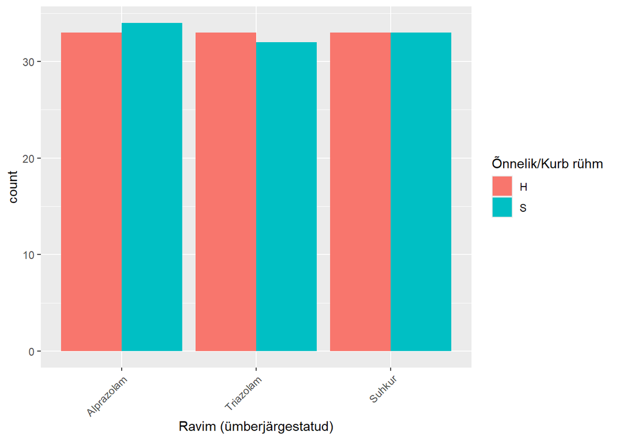

```r
# Tulpdiagramm ümberjärgestatud Drug ja Happy_Sad_group muutujatega
bar_plot_reordered <- ggplot(Isd_reordered, aes(x = Drug_reordered, fill = Happy_Sad_group)) +
  geom_bar(position = "dodge") +
  labs(x = "Ravim (ümberjärgestatud)", fill = "Õnnelik/Kurb rühm") +
  theme(axis.text.x = element_text(angle = 45, hjust = 1))

bar_plot_reordered
```

Selles joonises kasutasime refactored ja ümberjärgestatud Drug muutujat, et luua informatiivsem visualiseering. Faktorite ümberkodeerimine ja ümberjärgestamine parandab jooniste loetavust ja tõhusust.

## Jooniste täiustamine pealkirjade, teljesiltide, piiride ja teemadega

Pealkirjade, teljesiltide, piiride ja teema lisamine muudab joonised informatiivsemaks ja visuaalselt atraktiivsemaks. Selles osas näitame, kuidas joonist täiustada nende võimalustega.

Loome hajuvusdiagrammi **`Sepal.Length`** vs **`Sepal.Width`** ja kasutame **`Petal.Length`** värviskaalana **`iris`** andmestikus:

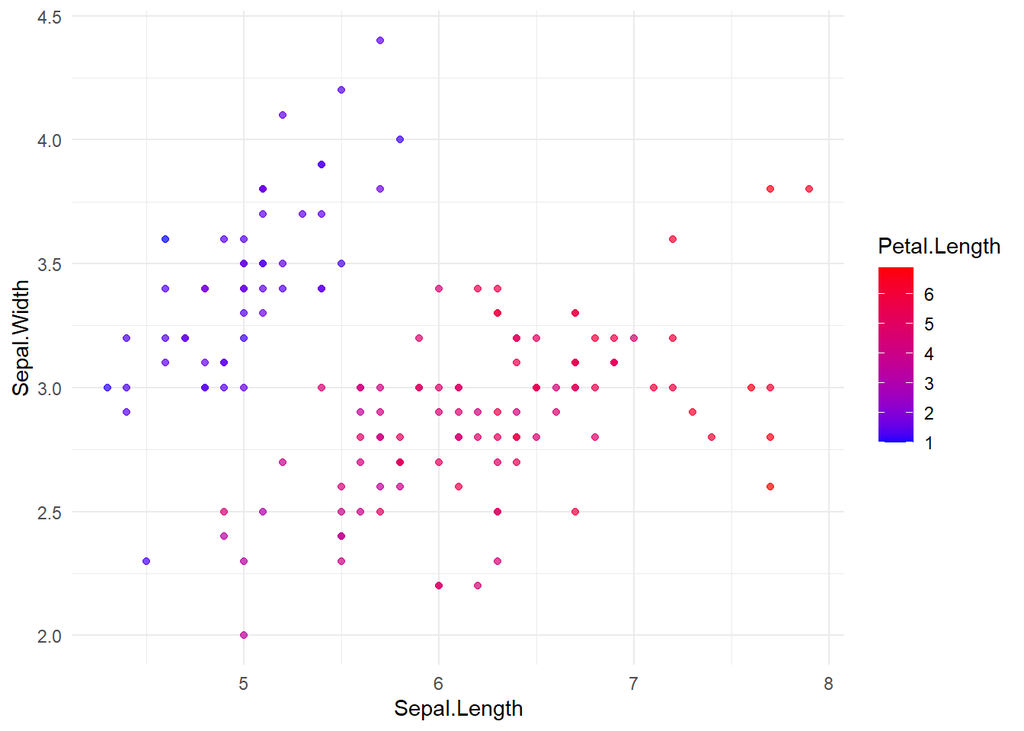

```r
# Hajuvusdiagramm Sepal.Length vs Sepal.Width ja Petal.Length värviskaalana
scatter_plot_example <- ggplot(iris, aes(x = Sepal.Length, y = Sepal.Width, color = Petal.Length)) +
  geom_point(alpha = 0.7) +
  scale_color_continuous(low = "blue", high = "red") +
  theme_minimal()

scatter_plot_example
```

### Pealkirja ja teljesiltide lisamine

Pealkirja, alapealkirja ja teljesilte saab lisada `labs()` funktsiooniga:

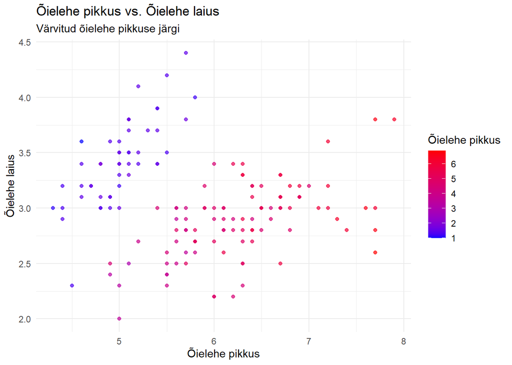

```r
# Lisa pealkiri, alapealkiri ja teljesildid
scatter_plot_labeled <- scatter_plot_example +
  labs(
    title = "Õielehe pikkus vs. Õielehe laius",
    subtitle = "Värvitud õielehe pikkuse järgi",
    x = "Õielehe pikkus",
    y = "Õielehe laius",
    color = "Õielehe pikkus"
  )

scatter_plot_labeled
```

### Telje piiride määramine

x- ja y-telje piirid saab määrata `xlim()` ja `ylim()` funktsioonidega:

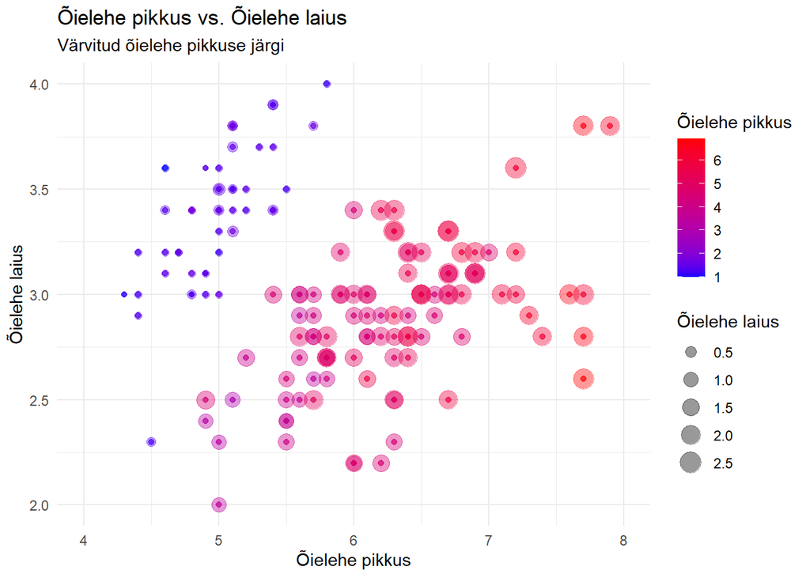

```r
# Määra x- ja y-telje piirid
scatter_plot_limited <- scatter_plot_labeled +
  xlim(4, 8) +
  ylim(2, 4) +
  geom_point(mapping = aes(size = Petal.Width), alpha=0.4) +
  labs(size = 'Õielehe laius')

scatter_plot_limited
```

### Teema kohandamine

Joonise välimust saab muuta teema abil. `theme()` funktsioon võimaldab muuta erinevaid joonise osi, nt teksti suurust, fonti, taustavärve ja ruudustikku:

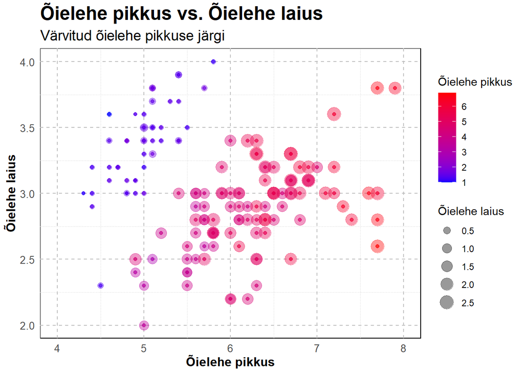

```r
scatter_plot_custom_theme <- scatter_plot_limited +
  theme(
    plot.title = element_text(size = 18, face = "bold"),
    plot.subtitle = element_text(size = 14),
    axis.title = element_text(size = 12, face = "bold"),
    axis.text = element_text(size = 10),
    panel.background = element_rect(fill = "white"),
    panel.grid.major = element_line(color = "gray", linetype = "dashed", linewidth = 0.5),
    panel.grid.minor = element_line(color = "gray", linetype = "dotted", linewidth = 0.25)
  )

scatter_plot_custom_theme
```

Pealkirjade, teljesiltide, piiride ja teema lisamine muudab joonised informatiivsemaks ja visuaalselt atraktiivsemaks. Vaata [spikrit](https://rstudio.github.io/cheatsheets/data-visualization.pdf) lisateemade jaoks.

## Jooniste eksportimine ja salvestamine ggsave abil

`ggsave()` on mugav funktsioon ggplot2 jooniste salvestamiseks erinevates failiformaatides, nt PNG, PDF, SVG või TIFF. `ggsave()` abil saab hõlpsalt salvestada kvaliteetseid jooniseid raportitesse, esitlustesse või publikatsioonidesse.

Joonise salvestamiseks PNG-failina kasuta `ggsave()` funktsiooni:

```r
# Salvesta joonis PNG-failina
ggsave(
  filename = "scatter_plot_custom_theme.png",
  plot = scatter_plot_custom_theme,
  width = 8,
  height = 5,
  dpi = 300
)
```

Teise failiformaadi jaoks muuda failinime laiendit. Näiteks PDF-i salvestamiseks:

```r
# Salvesta joonis PDF-failina
ggsave(
  filename = "scatter_plot_custom_theme.pdf",
  width = 8,
  height = 5
)
```

`ggsave()` abil saab ggplot2 jooniseid hõlpsalt eksportida ja salvestada erinevates failiformaatides, et neid jagada või dokumentidesse lisada.

## Mitme joonise kombineerimine patchwork paketiga

`patchwork` pakett võimaldab ggplot2 jooniseid lihtsalt ühte paigutusse kombineerida. See on kasulik erinevate visualiseeringute kõrvutamiseks või keerukamate jooniste loomiseks.

Loome esmalt mõned näidisjoonised mtcars andmestiku põhjal:

```r
# Laadi vajalikud paketid
# library(ggplot2)
library(patchwork)

# Hajuvusdiagramm mpg vs. wt
scatter_plot <- ggplot(mtcars, aes(x = wt, y = mpg)) +
  geom_point(aes(color = cyl)) +
  labs(title = "Kütusesäästlikkus vs. kaal", x = "Kaal (1000 lbs)", y = "Kütusesäästlikkus", color = "Silindrid") +
  theme_minimal()

# Tulpdiagramm autode arvust silindrite kaupa
bar_plot <- ggplot(mtcars, aes(x = factor(cyl))) +
  geom_bar(aes(fill = factor(cyl))) +
  labs(title = "Autode arv silindrite kaupa", x = "Silindrite arv", y = "Arv", fill = "Silindrid") +
  theme_minimal()

# Kastdiagramm mpg silindrite kaupa
box_plot <- ggplot(mtcars, aes(x = factor(cyl), y = mpg)) +
  geom_boxplot(aes(fill = factor(cyl))) +
  labs(title = "Kütusesäästlikkus silindrite kaupa", x = "Silindrite arv", y = "Kütusesäästlikkus", fill = "Silindrid") +
  theme_minimal() + theme(legend.position = "None")
```

Nüüd kombineerime joonised patchwork paketiga:

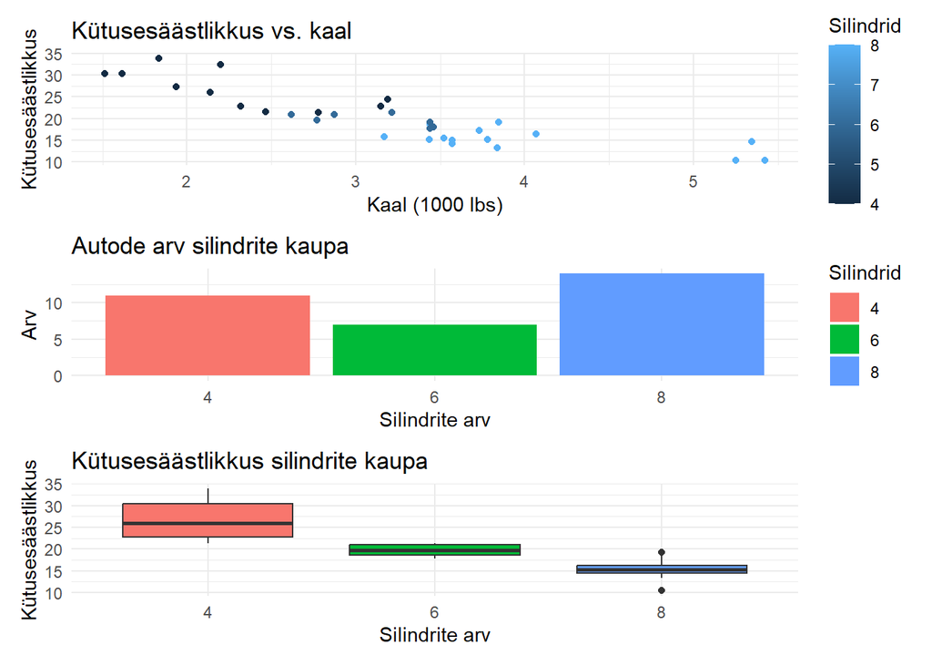

```r
# Kombineeri joonised patchwork abil
combined_plot <- scatter_plot + bar_plot + box_plot + plot_layout(ncol = 1)
combined_plot
```

Selles näites kombineerisime kolm joonist ühte veergu. Paigutust saab muuta `ncol` ja `nrow` parameetritega `plot_layout()` funktsioonis.

Legendide kogumiseks ja globaalse pealkirja, alapealkirja ning allkirja lisamiseks kasuta `plot_annotation()` funktsiooni:

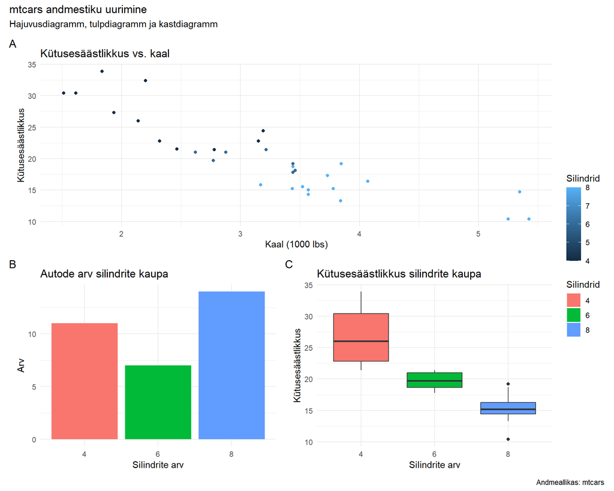

```r
# Kogu legendid ja lisa globaalne pealkiri, alapealkiri ja allkiri
combined_plot_annotated <- scatter_plot / (bar_plot + box_plot) +
  plot_annotation(
    title = "mtcars andmestiku uurimine",
    subtitle = "Hajuvusdiagramm, tulpdiagramm ja kastdiagramm",
    caption = "Andmeallikas: mtcars",
    tag_levels = 'A'
  ) +
  plot_layout(guides = "collect")

combined_plot_annotated
```

patchwork paketiga saab mitut ggplot2 joonist ühte paigutusse kombineerida, mis lihtsustab visualiseeringute võrdlemist ja esitamist.

### Ülesanne:

Nüüd on sinu kord särada. Lase fantaasial lennata ja uuri Islander näidisandmestikku. Koosta oma visualiseering. Kasuta nii palju jooniseid, värve ja teemasid, kui soovid. Alusta järk-järgult, nii on vigu lihtsam leida ja parandada. Võid kasutada ka oma andmeid. Proovi jõuda avaldamiskõlbliku kujutiseni (*ilma* legendita).

Uuri rohkem võimalusi erinevatelt [spikritelt](https://posit.co/resources/cheatsheets/).

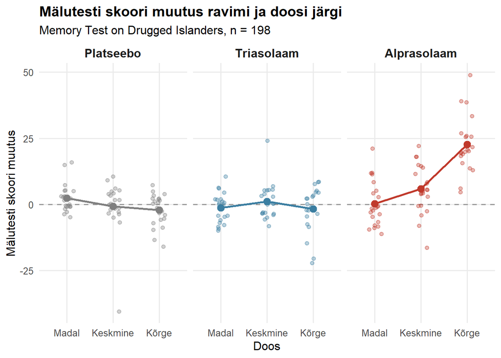

```r
Isd_plot <- Isd %>%
  mutate(
    Drug_name = fct_recode(Drug, "Alprasolaam" = "A", "Triasolaam" = "T", "Platseebo" = "S"),
    Drug_name = fct_relevel(Drug_name, "Platseebo", "Triasolaam", "Alprasolaam")
  )

final_plot <- ggplot(Isd_plot, aes(x = factor(Dosage), y = Diff, color = Drug_name)) +
  geom_hline(yintercept = 0, linetype = "dashed", color = "grey60") +
  geom_jitter(width = 0.15, height = 0, alpha = 0.35) +
  stat_summary(aes(group = 1), fun = mean, geom = "line", linewidth = 1) +
  stat_summary(fun = mean, geom = "point", size = 3) +
  facet_wrap(~ Drug_name) +
  scale_x_discrete(labels = c("Madal", "Keskmine", "Kõrge")) +
  scale_color_manual(values = c(Platseebo = "grey50",
                                Triasolaam = "#3B7EA1",
                                Alprasolaam = "#C0392B")) +
  labs(
    title = "Mälutesti skoori muutus ravimi ja doosi järgi",
    subtitle = "Memory Test on Drugged Islanders, n = 198",
    x = "Doos",
    y = "Mälutesti skoori muutus"
  ) +
  theme_minimal(base_size = 12) +
  theme(
    legend.position = "none",
    plot.title = element_text(face = "bold"),
    strip.text = element_text(face = "bold", size = 12),
    panel.grid.minor = element_blank()
  )

final_plot
```

Joonisel on iga ravim eraldi paneelil. Punktid näitavad üksikuid osalejaid ning suur punkt koos joonega rühma keskmist. Alprasolaami korral kasvas mälu paranemine doosiga ja kõrge doosi juures oli see keskmiselt umbes 22 punkti. Platseebo ja triasolaami puhul mälu skoor keskmiselt ei muutunud. Hajuvus on aga suur, nii et efekt erines inimeseti märgatavalt.

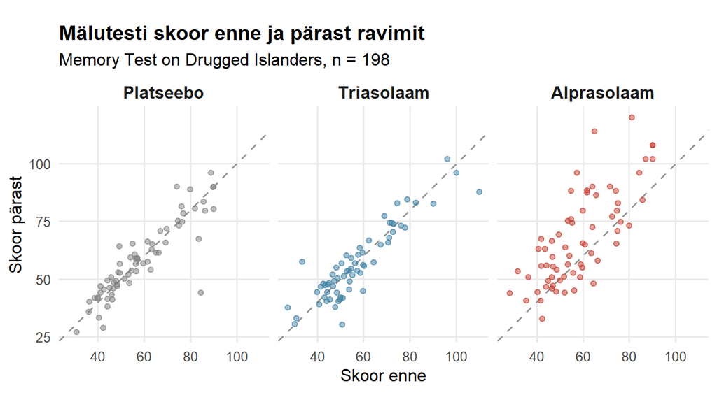

```r
before_after_plot <- ggplot(Isd_plot, aes(x = Mem_Score_Before, y = Mem_Score_After, color = Drug_name)) +
  geom_abline(slope = 1, intercept = 0, linetype = "dashed", color = "grey60") +
  geom_point(alpha = 0.5) +
  facet_wrap(~ Drug_name) +
  coord_equal() +
  scale_color_manual(values = c(Platseebo = "grey50",
                                Triasolaam = "#3B7EA1",
                                Alprasolaam = "#C0392B")) +
  labs(
    title = "Mälutesti skoor enne ja pärast ravimit",
    subtitle = "Memory Test on Drugged Islanders, n = 198",
    x = "Skoor enne",
    y = "Skoor pärast"
  ) +
  theme_minimal(base_size = 12) +
  theme(
    legend.position = "none",
    plot.title = element_text(face = "bold"),
    strip.text = element_text(face = "bold", size = 12),
    panel.grid.minor = element_blank()
  )

before_after_plot
```

Joonisel on iga osaleja mälutesti skoor enne ja pärast ravimit. Punktid katkendjoonest kõrgemal tähistavad paranemist. Platseebo ja triasolaami puhul on punktid tihedalt joone ümber, ehk skoor jäi enamasti samaks. Alprasolaami korral on enamik punkte joonest kõrgemal, nii et mälu paranes enamikel osalejatest, aga väga erineval määral.

#### Boonus

Uuri [‘esquisse’](https://cran.r-project.org/web/packages/esquisse/vignettes/get-started.html) paketti interaktiivseks jooniste koostamiseks. See käivitab shiny rakenduse, mis võimaldab graafikuid lohistades ehitada.